# Risk Factor Analysis

## Outcome Variable

**Outcome Variable:** ever_wasted

## Predictor Variables

**Intervention Variable:** predfeed3

**Adjustment Set:**

- arm
- sex
- month
- brthmon
- W_mage
- meducyrs
- feducyrs
- hhwealth_quart
- hfoodsec
- W_mhtcm
- W_mwtkg
- W_mbmi
- vagbrth
- W_gagebrth
- W_birthwt
- W_birthlen
- W_nrooms
- W_nchldlt5
- W_parity
- impfloor
- impsan
- safeh20
- delta_W_mage
- delta_meducyrs
- delta_feducyrs
- delta_hhwealth_quart
- delta_hfoodsec
- delta_W_mhtcm
- delta_W_mwtkg
- delta_W_mbmi
- delta_vagbrth
- delta_W_gagebrth
- delta_W_birthwt
- delta_W_birthlen
- delta_W_nrooms
- delta_W_nchldlt5
- delta_W_parity
- delta_impfloor
- delta_impsan
- delta_safeh20

## Stratifying Variables

The analysis was stratified on these variable(s):

- agecat
- studyid
- country

## Data Summary

| agecat | studyid | country | predfeed3 | ever_wasted | n_cell | n |
| --- | --- | --- | --- | --- | --- | --- |
| 0-24 months (no birth wast) | EE | PAKISTAN | 1 | 0 | 18 | 39 |
| 0-24 months (no birth wast) | EE | PAKISTAN | 1 | 1 | 21 | 39 |
| 0-24 months (no birth wast) | EE | PAKISTAN | 0 | 0 | 0 | 39 |
| 0-24 months (no birth wast) | EE | PAKISTAN | 0 | 1 | 0 | 39 |
| 0-24 months (no birth wast) | GMS-Nepal | NEPAL | 1 | 0 | 147 | 453 |
| 0-24 months (no birth wast) | GMS-Nepal | NEPAL | 1 | 1 | 229 | 453 |
| 0-24 months (no birth wast) | GMS-Nepal | NEPAL | 0 | 0 | 39 | 453 |
| 0-24 months (no birth wast) | GMS-Nepal | NEPAL | 0 | 1 | 38 | 453 |
| 0-24 months (no birth wast) | JiVitA-3 | BANGLADESH | 1 | 0 | 11036 | 14768 |
| 0-24 months (no birth wast) | JiVitA-3 | BANGLADESH | 1 | 1 | 2328 | 14768 |
| 0-24 months (no birth wast) | JiVitA-3 | BANGLADESH | 0 | 0 | 1165 | 14768 |
| 0-24 months (no birth wast) | JiVitA-3 | BANGLADESH | 0 | 1 | 239 | 14768 |
| 0-24 months (no birth wast) | JiVitA-4 | BANGLADESH | 1 | 0 | 109 | 164 |
| 0-24 months (no birth wast) | JiVitA-4 | BANGLADESH | 1 | 1 | 38 | 164 |
| 0-24 months (no birth wast) | JiVitA-4 | BANGLADESH | 0 | 0 | 13 | 164 |
| 0-24 months (no birth wast) | JiVitA-4 | BANGLADESH | 0 | 1 | 4 | 164 |
| 0-24 months (no birth wast) | MAL-ED | BANGLADESH | 1 | 0 | 152 | 244 |
| 0-24 months (no birth wast) | MAL-ED | BANGLADESH | 1 | 1 | 48 | 244 |
| 0-24 months (no birth wast) | MAL-ED | BANGLADESH | 0 | 0 | 37 | 244 |
| 0-24 months (no birth wast) | MAL-ED | BANGLADESH | 0 | 1 | 7 | 244 |
| 0-24 months (no birth wast) | MAL-ED | BRAZIL | 1 | 0 | 89 | 202 |
| 0-24 months (no birth wast) | MAL-ED | BRAZIL | 1 | 1 | 9 | 202 |
| 0-24 months (no birth wast) | MAL-ED | BRAZIL | 0 | 0 | 100 | 202 |
| 0-24 months (no birth wast) | MAL-ED | BRAZIL | 0 | 1 | 4 | 202 |
| 0-24 months (no birth wast) | MAL-ED | INDIA | 1 | 0 | 94 | 212 |
| 0-24 months (no birth wast) | MAL-ED | INDIA | 1 | 1 | 56 | 212 |
| 0-24 months (no birth wast) | MAL-ED | INDIA | 0 | 0 | 36 | 212 |
| 0-24 months (no birth wast) | MAL-ED | INDIA | 0 | 1 | 26 | 212 |
| 0-24 months (no birth wast) | MAL-ED | NEPAL | 1 | 0 | 88 | 227 |
| 0-24 months (no birth wast) | MAL-ED | NEPAL | 1 | 1 | 25 | 227 |

[output cut: 102 more lines]

The following strata were considered:

- agecat: 0-24 months (no birth wast), studyid: EE, country: PAKISTAN
- agecat: 0-24 months (no birth wast), studyid: GMS-Nepal, country: NEPAL
- agecat: 0-24 months (no birth wast), studyid: JiVitA-3, country: BANGLADESH
- agecat: 0-24 months (no birth wast), studyid: JiVitA-4, country: BANGLADESH
- agecat: 0-24 months (no birth wast), studyid: MAL-ED, country: BANGLADESH
- agecat: 0-24 months (no birth wast), studyid: MAL-ED, country: BRAZIL
- agecat: 0-24 months (no birth wast), studyid: MAL-ED, country: INDIA
- agecat: 0-24 months (no birth wast), studyid: MAL-ED, country: NEPAL
- agecat: 0-24 months (no birth wast), studyid: MAL-ED, country: PERU
- agecat: 0-24 months (no birth wast), studyid: MAL-ED, country: SOUTH AFRICA
- agecat: 0-24 months (no birth wast), studyid: MAL-ED, country: TANZANIA, UNITED REPUBLIC OF
- agecat: 0-6 months (no birth wast), studyid: EE, country: PAKISTAN
- agecat: 0-6 months (no birth wast), studyid: GMS-Nepal, country: NEPAL
- agecat: 0-6 months (no birth wast), studyid: JiVitA-3, country: BANGLADESH
- agecat: 0-6 months (no birth wast), studyid: JiVitA-4, country: BANGLADESH
- agecat: 0-6 months (no birth wast), studyid: MAL-ED, country: BANGLADESH
- agecat: 0-6 months (no birth wast), studyid: MAL-ED, country: BRAZIL
- agecat: 0-6 months (no birth wast), studyid: MAL-ED, country: INDIA
- agecat: 0-6 months (no birth wast), studyid: MAL-ED, country: NEPAL
- agecat: 0-6 months (no birth wast), studyid: MAL-ED, country: PERU
- agecat: 0-6 months (no birth wast), studyid: MAL-ED, country: SOUTH AFRICA
- agecat: 0-6 months (no birth wast), studyid: MAL-ED, country: TANZANIA, UNITED REPUBLIC OF
- agecat: 6-24 months, studyid: EE, country: PAKISTAN
- agecat: 6-24 months, studyid: GMS-Nepal, country: NEPAL
- agecat: 6-24 months, studyid: JiVitA-3, country: BANGLADESH
- agecat: 6-24 months, studyid: JiVitA-4, country: BANGLADESH
- agecat: 6-24 months, studyid: MAL-ED, country: BANGLADESH
- agecat: 6-24 months, studyid: MAL-ED, country: BRAZIL
- agecat: 6-24 months, studyid: MAL-ED, country: INDIA
- agecat: 6-24 months, studyid: MAL-ED, country: NEPAL
- agecat: 6-24 months, studyid: MAL-ED, country: PERU
- agecat: 6-24 months, studyid: MAL-ED, country: SOUTH AFRICA
- agecat: 6-24 months, studyid: MAL-ED, country: TANZANIA, UNITED REPUBLIC OF

### Dropped Strata

Some strata were dropped due to rare outcomes:

- agecat: 0-24 months (no birth wast), studyid: EE, country: PAKISTAN
- agecat: 0-24 months (no birth wast), studyid: JiVitA-4, country: BANGLADESH
- agecat: 0-24 months (no birth wast), studyid: MAL-ED, country: BRAZIL
- agecat: 0-6 months (no birth wast), studyid: EE, country: PAKISTAN
- agecat: 0-6 months (no birth wast), studyid: JiVitA-4, country: BANGLADESH
- agecat: 0-6 months (no birth wast), studyid: MAL-ED, country: BANGLADESH
- agecat: 0-6 months (no birth wast), studyid: MAL-ED, country: BRAZIL
- agecat: 0-6 months (no birth wast), studyid: MAL-ED, country: PERU
- agecat: 0-6 months (no birth wast), studyid: MAL-ED, country: TANZANIA, UNITED REPUBLIC OF
- agecat: 6-24 months, studyid: EE, country: PAKISTAN
- agecat: 6-24 months, studyid: JiVitA-4, country: BANGLADESH
- agecat: 6-24 months, studyid: MAL-ED, country: BANGLADESH
- agecat: 6-24 months, studyid: MAL-ED, country: BRAZIL

## Methods Detail

We’re interested in the causal parameters $E[Y_a]$ for all values of $a \in \mathcal{A}$. These parameters represent the mean outcome if, possibly contrary to fact, we intervened to set all units to have $A=a$. Under the randomization and positivity assumptions, these are identified by the statistical parameters $\psi_a=E_W[E_{Y|A,W}(Y|A=a,W)]$. In addition, we’re interested in the mean of $Y$, $E[Y]$ under no intervention (the observed mean). We will estimate these parameters by using SuperLearner to fit the relevant likelihood factors – $E_{Y|A,W}(Y|A=a,W)$ and $p(A=a|W)$, and then updating our likelihood fit using a joint TMLE.

For unadjusted analyses ($W=\{\}$), initial likelihoods were estimated using Lrnr_glm to estimate the simple $E(Y|A)$ and Lrnr_mean to estimate $p(A)$. For adjusted analyses, a small library containing Lrnr_glmnet, Lrnr_xgboost, and Lrnr_mean was used.

Having estimated these parameters, we will then use the delta method to estimate relative risks and attributable risks relative to a prespecified baseline level of $A$.

# Results Detail

## Results Plots

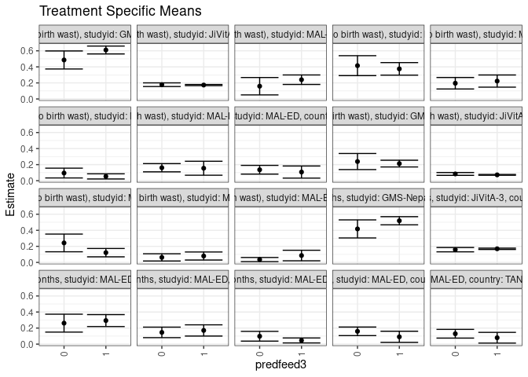

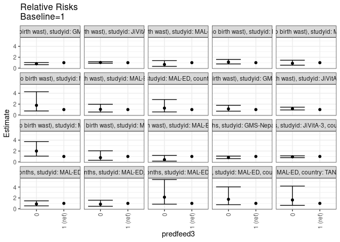

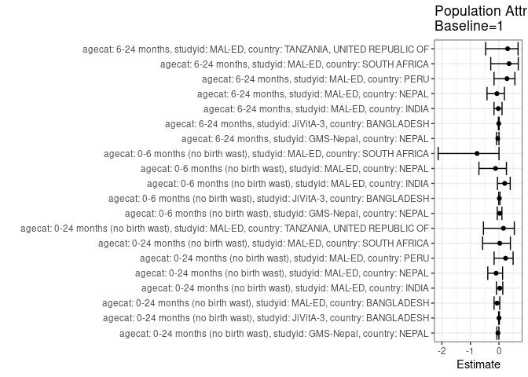

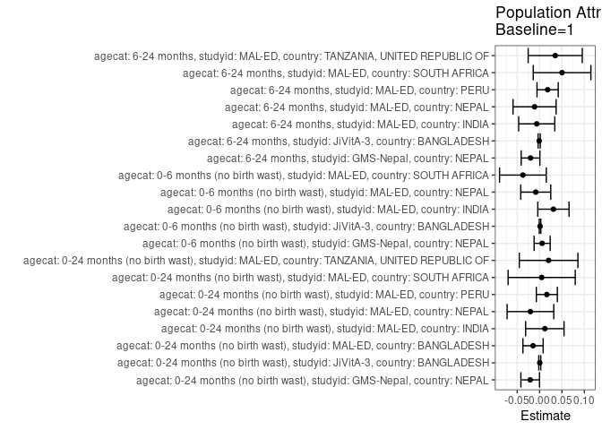

## Results Table

### Parameter: TSM

| agecat | studyid | country | intervention_level | baseline_level | estimate | ci_lower | ci_upper |
| --- | --- | --- | --- | --- | --- | --- | --- |
| 0-24 months (no birth wast) | GMS-Nepal | NEPAL | 1 | NA | 0.6103276 | 0.5611372 | 0.6595180 |
| 0-24 months (no birth wast) | GMS-Nepal | NEPAL | 0 | NA | 0.4859963 | 0.3736288 | 0.5983638 |
| 0-24 months (no birth wast) | JiVitA-3 | BANGLADESH | 1 | NA | 0.1734168 | 0.1664587 | 0.1803748 |
| 0-24 months (no birth wast) | JiVitA-3 | BANGLADESH | 0 | NA | 0.1778614 | 0.1548699 | 0.2008529 |
| 0-24 months (no birth wast) | MAL-ED | BANGLADESH | 1 | NA | 0.2400000 | 0.1806887 | 0.2993113 |
| 0-24 months (no birth wast) | MAL-ED | BANGLADESH | 0 | NA | 0.1590909 | 0.0507953 | 0.2673865 |
| 0-24 months (no birth wast) | MAL-ED | INDIA | 1 | NA | 0.3750361 | 0.2969438 | 0.4531285 |
| 0-24 months (no birth wast) | MAL-ED | INDIA | 0 | NA | 0.4151072 | 0.2909952 | 0.5392192 |
| 0-24 months (no birth wast) | MAL-ED | NEPAL | 1 | NA | 0.2230545 | 0.1471493 | 0.2989596 |
| 0-24 months (no birth wast) | MAL-ED | NEPAL | 0 | NA | 0.1958915 | 0.1241875 | 0.2675954 |
| 0-24 months (no birth wast) | MAL-ED | PERU | 1 | NA | 0.0534304 | 0.0213149 | 0.0855460 |
| 0-24 months (no birth wast) | MAL-ED | PERU | 0 | NA | 0.0950963 | 0.0340896 | 0.1561029 |
| 0-24 months (no birth wast) | MAL-ED | SOUTH AFRICA | 1 | NA | 0.1551587 | 0.0681659 | 0.2421515 |
| 0-24 months (no birth wast) | MAL-ED | SOUTH AFRICA | 0 | NA | 0.1614137 | 0.1099575 | 0.2128699 |
| 0-24 months (no birth wast) | MAL-ED | TANZANIA, UNITED REPUBLIC OF | 1 | NA | 0.1076923 | 0.0321596 | 0.1832250 |
| 0-24 months (no birth wast) | MAL-ED | TANZANIA, UNITED REPUBLIC OF | 0 | NA | 0.1363636 | 0.0820391 | 0.1906882 |
| 0-6 months (no birth wast) | GMS-Nepal | NEPAL | 1 | NA | 0.2129265 | 0.1708905 | 0.2549625 |
| 0-6 months (no birth wast) | GMS-Nepal | NEPAL | 0 | NA | 0.2386360 | 0.1383334 | 0.3389387 |
| 0-6 months (no birth wast) | JiVitA-3 | BANGLADESH | 1 | NA | 0.0725118 | 0.0673891 | 0.0776345 |
| 0-6 months (no birth wast) | JiVitA-3 | BANGLADESH | 0 | NA | 0.0839179 | 0.0662941 | 0.1015417 |
| 0-6 months (no birth wast) | MAL-ED | INDIA | 1 | NA | 0.1214775 | 0.0694126 | 0.1735425 |
| 0-6 months (no birth wast) | MAL-ED | INDIA | 0 | NA | 0.2426449 | 0.1322351 | 0.3530546 |
| 0-6 months (no birth wast) | MAL-ED | NEPAL | 1 | NA | 0.0796460 | 0.0296154 | 0.1296766 |
| 0-6 months (no birth wast) | MAL-ED | NEPAL | 0 | NA | 0.0625000 | 0.0175705 | 0.1074295 |
| 0-6 months (no birth wast) | MAL-ED | SOUTH AFRICA | 1 | NA | 0.0857143 | 0.0200123 | 0.1514163 |
| 0-6 months (no birth wast) | MAL-ED | SOUTH AFRICA | 0 | NA | 0.0353535 | 0.0095827 | 0.0611243 |
| 6-24 months | GMS-Nepal | NEPAL | 1 | NA | 0.5190706 | 0.4684102 | 0.5697311 |
| 6-24 months | GMS-Nepal | NEPAL | 0 | NA | 0.4172374 | 0.3045795 | 0.5298953 |
| 6-24 months | JiVitA-3 | BANGLADESH | 1 | NA | 0.1693792 | 0.1610910 | 0.1776674 |
| 6-24 months | JiVitA-3 | BANGLADESH | 0 | NA | 0.1586396 | 0.1317642 | 0.1855151 |
| 6-24 months | MAL-ED | INDIA | 1 | NA | 0.2934430 | 0.2188876 | 0.3679984 |
| 6-24 months | MAL-ED | INDIA | 0 | NA | 0.2611394 | 0.1496559 | 0.3726230 |
| 6-24 months | MAL-ED | NEPAL | 1 | NA | 0.1704874 | 0.1004472 | 0.2405276 |
| 6-24 months | MAL-ED | NEPAL | 0 | NA | 0.1459450 | 0.0802869 | 0.2116030 |
| 6-24 months | MAL-ED | PERU | 1 | NA | 0.0457143 | 0.0147109 | 0.0767177 |
| 6-24 months | MAL-ED | PERU | 0 | NA | 0.0978261 | 0.0370068 | 0.1586454 |
| 6-24 months | MAL-ED | SOUTH AFRICA | 1 | NA | 0.0909091 | 0.0214129 | 0.1604052 |
| 6-24 months | MAL-ED | SOUTH AFRICA | 0 | NA | 0.1593407 | 0.1060608 | 0.2126205 |
| 6-24 months | MAL-ED | TANZANIA, UNITED REPUBLIC OF | 1 | NA | 0.0793651 | 0.0124579 | 0.1462723 |
| 6-24 months | MAL-ED | TANZANIA, UNITED REPUBLIC OF | 0 | NA | 0.1292517 | 0.0748903 | 0.1836131 |

### Parameter: E(Y)

| agecat | studyid | country | intervention_level | baseline_level | estimate | ci_lower | ci_upper |
| --- | --- | --- | --- | --- | --- | --- | --- |
| 0-24 months (no birth wast) | GMS-Nepal | NEPAL | NA | NA | 0.5894040 | 0.5440524 | 0.6347556 |
| 0-24 months (no birth wast) | JiVitA-3 | BANGLADESH | NA | NA | 0.1738218 | 0.1671074 | 0.1805361 |
| 0-24 months (no birth wast) | MAL-ED | BANGLADESH | NA | NA | 0.2254098 | 0.1728726 | 0.2779471 |
| 0-24 months (no birth wast) | MAL-ED | INDIA | NA | NA | 0.3867925 | 0.3210797 | 0.4525052 |
| 0-24 months (no birth wast) | MAL-ED | NEPAL | NA | NA | 0.2026432 | 0.1502365 | 0.2550498 |
| 0-24 months (no birth wast) | MAL-ED | PERU | NA | NA | 0.0696864 | 0.0401775 | 0.0991954 |
| 0-24 months (no birth wast) | MAL-ED | SOUTH AFRICA | NA | NA | 0.1598513 | 0.1159763 | 0.2037263 |
| 0-24 months (no birth wast) | MAL-ED | TANZANIA, UNITED REPUBLIC OF | NA | NA | 0.1278539 | 0.0835266 | 0.1721812 |
| 0-6 months (no birth wast) | GMS-Nepal | NEPAL | NA | NA | 0.2186788 | 0.1799683 | 0.2573894 |
| 0-6 months (no birth wast) | JiVitA-3 | BANGLADESH | NA | NA | 0.0735505 | 0.0685774 | 0.0785236 |
| 0-6 months (no birth wast) | MAL-ED | INDIA | NA | NA | 0.1523810 | 0.1036572 | 0.2011047 |
| 0-6 months (no birth wast) | MAL-ED | NEPAL | NA | NA | 0.0711111 | 0.0374542 | 0.1047681 |
| 0-6 months (no birth wast) | MAL-ED | SOUTH AFRICA | NA | NA | 0.0485075 | 0.0227384 | 0.0742766 |
| 6-24 months | GMS-Nepal | NEPAL | NA | NA | 0.4988914 | 0.4526947 | 0.5450880 |
| 6-24 months | JiVitA-3 | BANGLADESH | NA | NA | 0.1684342 | 0.1604630 | 0.1764054 |
| 6-24 months | MAL-ED | INDIA | NA | NA | 0.2870813 | 0.2256006 | 0.3485621 |
| 6-24 months | MAL-ED | NEPAL | NA | NA | 0.1592920 | 0.1114757 | 0.2071084 |
| 6-24 months | MAL-ED | PERU | NA | NA | 0.0636704 | 0.0343284 | 0.0930125 |
| 6-24 months | MAL-ED | SOUTH AFRICA | NA | NA | 0.1411290 | 0.0977108 | 0.1845472 |
| 6-24 months | MAL-ED | TANZANIA, UNITED REPUBLIC OF | NA | NA | 0.1142857 | 0.0711519 | 0.1574195 |

### Parameter: RR

| agecat | studyid | country | intervention_level | baseline_level | estimate | ci_lower | ci_upper |
| --- | --- | --- | --- | --- | --- | --- | --- |
| 0-24 months (no birth wast) | GMS-Nepal | NEPAL | 1 | 1 | 1.0000000 | 1.0000000 | 1.000000 |
| 0-24 months (no birth wast) | GMS-Nepal | NEPAL | 0 | 1 | 0.7962875 | 0.6241610 | 1.015882 |
| 0-24 months (no birth wast) | JiVitA-3 | BANGLADESH | 1 | 1 | 1.0000000 | 1.0000000 | 1.000000 |
| 0-24 months (no birth wast) | JiVitA-3 | BANGLADESH | 0 | 1 | 1.0256299 | 0.8967560 | 1.173024 |
| 0-24 months (no birth wast) | MAL-ED | BANGLADESH | 1 | 1 | 1.0000000 | 1.0000000 | 1.000000 |
| 0-24 months (no birth wast) | MAL-ED | BANGLADESH | 0 | 1 | 0.6628788 | 0.3213097 | 1.367554 |
| 0-24 months (no birth wast) | MAL-ED | INDIA | 1 | 1 | 1.0000000 | 1.0000000 | 1.000000 |
| 0-24 months (no birth wast) | MAL-ED | INDIA | 0 | 1 | 1.1068459 | 0.7678246 | 1.595557 |
| 0-24 months (no birth wast) | MAL-ED | NEPAL | 1 | 1 | 1.0000000 | 1.0000000 | 1.000000 |
| 0-24 months (no birth wast) | MAL-ED | NEPAL | 0 | 1 | 0.8782227 | 0.5328577 | 1.447431 |
| 0-24 months (no birth wast) | MAL-ED | PERU | 1 | 1 | 1.0000000 | 1.0000000 | 1.000000 |
| 0-24 months (no birth wast) | MAL-ED | PERU | 0 | 1 | 1.7798141 | 0.7406068 | 4.277220 |
| 0-24 months (no birth wast) | MAL-ED | SOUTH AFRICA | 1 | 1 | 1.0000000 | 1.0000000 | 1.000000 |
| 0-24 months (no birth wast) | MAL-ED | SOUTH AFRICA | 0 | 1 | 1.0403136 | 0.5462655 | 1.981184 |
| 0-24 months (no birth wast) | MAL-ED | TANZANIA, UNITED REPUBLIC OF | 1 | 1 | 1.0000000 | 1.0000000 | 1.000000 |
| 0-24 months (no birth wast) | MAL-ED | TANZANIA, UNITED REPUBLIC OF | 0 | 1 | 1.2662338 | 0.5652023 | 2.836768 |
| 0-6 months (no birth wast) | GMS-Nepal | NEPAL | 1 | 1 | 1.0000000 | 1.0000000 | 1.000000 |
| 0-6 months (no birth wast) | GMS-Nepal | NEPAL | 0 | 1 | 1.1207436 | 0.7043791 | 1.783225 |
| 0-6 months (no birth wast) | JiVitA-3 | BANGLADESH | 1 | 1 | 1.0000000 | 1.0000000 | 1.000000 |
| 0-6 months (no birth wast) | JiVitA-3 | BANGLADESH | 0 | 1 | 1.1572998 | 0.9290098 | 1.441689 |
| 0-6 months (no birth wast) | MAL-ED | INDIA | 1 | 1 | 1.0000000 | 1.0000000 | 1.000000 |
| 0-6 months (no birth wast) | MAL-ED | INDIA | 0 | 1 | 1.9974466 | 1.0664395 | 3.741228 |
| 0-6 months (no birth wast) | MAL-ED | NEPAL | 1 | 1 | 1.0000000 | 1.0000000 | 1.000000 |
| 0-6 months (no birth wast) | MAL-ED | NEPAL | 0 | 1 | 0.7847222 | 0.3020750 | 2.038530 |
| 0-6 months (no birth wast) | MAL-ED | SOUTH AFRICA | 1 | 1 | 1.0000000 | 1.0000000 | 1.000000 |
| 0-6 months (no birth wast) | MAL-ED | SOUTH AFRICA | 0 | 1 | 0.4124579 | 0.1432147 | 1.187878 |
| 6-24 months | GMS-Nepal | NEPAL | 1 | 1 | 1.0000000 | 1.0000000 | 1.000000 |
| 6-24 months | GMS-Nepal | NEPAL | 0 | 1 | 0.8038162 | 0.6032742 | 1.071023 |
| 6-24 months | JiVitA-3 | BANGLADESH | 1 | 1 | 1.0000000 | 1.0000000 | 1.000000 |
| 6-24 months | JiVitA-3 | BANGLADESH | 0 | 1 | 0.9365945 | 0.7860128 | 1.116024 |
| 6-24 months | MAL-ED | INDIA | 1 | 1 | 1.0000000 | 1.0000000 | 1.000000 |
| 6-24 months | MAL-ED | INDIA | 0 | 1 | 0.8899154 | 0.5412977 | 1.463057 |
| 6-24 months | MAL-ED | NEPAL | 1 | 1 | 1.0000000 | 1.0000000 | 1.000000 |
| 6-24 months | MAL-ED | NEPAL | 0 | 1 | 0.8560456 | 0.4649887 | 1.575982 |
| 6-24 months | MAL-ED | PERU | 1 | 1 | 1.0000000 | 1.0000000 | 1.000000 |
| 6-24 months | MAL-ED | PERU | 0 | 1 | 2.1399457 | 0.8527742 | 5.369965 |
| 6-24 months | MAL-ED | SOUTH AFRICA | 1 | 1 | 1.0000000 | 1.0000000 | 1.000000 |
| 6-24 months | MAL-ED | SOUTH AFRICA | 0 | 1 | 1.7527473 | 0.7609377 | 4.037286 |
| 6-24 months | MAL-ED | TANZANIA, UNITED REPUBLIC OF | 1 | 1 | 1.0000000 | 1.0000000 | 1.000000 |
| 6-24 months | MAL-ED | TANZANIA, UNITED REPUBLIC OF | 0 | 1 | 1.6285714 | 0.6348173 | 4.177966 |

### Parameter: PAR

| agecat | studyid | country | intervention_level | baseline_level | estimate | ci_lower | ci_upper |
| --- | --- | --- | --- | --- | --- | --- | --- |
| 0-24 months (no birth wast) | GMS-Nepal | NEPAL | 1 | NA | -0.0209237 | -0.0417528 | -0.0000945 |
| 0-24 months (no birth wast) | JiVitA-3 | BANGLADESH | 1 | NA | 0.0004050 | -0.0018264 | 0.0026364 |
| 0-24 months (no birth wast) | MAL-ED | BANGLADESH | 1 | NA | -0.0145902 | -0.0371968 | 0.0080165 |
| 0-24 months (no birth wast) | MAL-ED | INDIA | 1 | NA | 0.0117563 | -0.0311242 | 0.0546368 |
| 0-24 months (no birth wast) | MAL-ED | NEPAL | 1 | NA | -0.0204113 | -0.0725523 | 0.0317297 |
| 0-24 months (no birth wast) | MAL-ED | PERU | 1 | NA | 0.0162560 | -0.0072426 | 0.0397545 |
| 0-24 months (no birth wast) | MAL-ED | SOUTH AFRICA | 1 | NA | 0.0046926 | -0.0702871 | 0.0796722 |
| 0-24 months (no birth wast) | MAL-ED | TANZANIA, UNITED REPUBLIC OF | 1 | NA | 0.0201616 | -0.0452865 | 0.0856097 |
| 0-6 months (no birth wast) | GMS-Nepal | NEPAL | 1 | NA | 0.0057523 | -0.0121812 | 0.0236858 |
| 0-6 months (no birth wast) | JiVitA-3 | BANGLADESH | 1 | NA | 0.0010387 | -0.0006938 | 0.0027712 |
| 0-6 months (no birth wast) | MAL-ED | INDIA | 1 | NA | 0.0309034 | -0.0039944 | 0.0658013 |
| 0-6 months (no birth wast) | MAL-ED | NEPAL | 1 | NA | -0.0085349 | -0.0420262 | 0.0249564 |
| 0-6 months (no birth wast) | MAL-ED | SOUTH AFRICA | 1 | NA | -0.0372068 | -0.0894158 | 0.0150022 |
| 6-24 months | GMS-Nepal | NEPAL | 1 | NA | -0.0201793 | -0.0410460 | 0.0006875 |
| 6-24 months | JiVitA-3 | BANGLADESH | 1 | NA | -0.0009450 | -0.0033410 | 0.0014510 |
| 6-24 months | MAL-ED | INDIA | 1 | NA | -0.0063617 | -0.0467064 | 0.0339831 |
| 6-24 months | MAL-ED | NEPAL | 1 | NA | -0.0111954 | -0.0592831 | 0.0368924 |
| 6-24 months | MAL-ED | PERU | 1 | NA | 0.0179561 | -0.0057536 | 0.0416659 |
| 6-24 months | MAL-ED | SOUTH AFRICA | 1 | NA | 0.0502199 | -0.0141555 | 0.1145954 |
| 6-24 months | MAL-ED | TANZANIA, UNITED REPUBLIC OF | 1 | NA | 0.0349206 | -0.0255041 | 0.0953454 |

### Parameter: PAF

| agecat | studyid | country | intervention_level | baseline_level | estimate | ci_lower | ci_upper |
| --- | --- | --- | --- | --- | --- | --- | --- |
| 0-24 months (no birth wast) | GMS-Nepal | NEPAL | 1 | NA | -0.0354997 | -0.0716636 | -0.0005561 |
| 0-24 months (no birth wast) | JiVitA-3 | BANGLADESH | 1 | NA | 0.0023301 | -0.0105854 | 0.0150806 |
| 0-24 months (no birth wast) | MAL-ED | BANGLADESH | 1 | NA | -0.0647273 | -0.1694188 | 0.0305918 |
| 0-24 months (no birth wast) | MAL-ED | INDIA | 1 | NA | 0.0303943 | -0.0871286 | 0.1352126 |
| 0-24 months (no birth wast) | MAL-ED | NEPAL | 1 | NA | -0.1007253 | -0.3904712 | 0.1286435 |
| 0-24 months (no birth wast) | MAL-ED | PERU | 1 | NA | 0.2332731 | -0.1691829 | 0.4971957 |
| 0-24 months (no birth wast) | MAL-ED | SOUTH AFRICA | 1 | NA | 0.0293560 | -0.5738847 | 0.4013858 |
| 0-24 months (no birth wast) | MAL-ED | TANZANIA, UNITED REPUBLIC OF | 1 | NA | 0.1576923 | -0.5426579 | 0.5400910 |
| 0-6 months (no birth wast) | GMS-Nepal | NEPAL | 1 | NA | 0.0263049 | -0.0592063 | 0.1049126 |
| 0-6 months (no birth wast) | JiVitA-3 | BANGLADESH | 1 | NA | 0.0141222 | -0.0096515 | 0.0373360 |
| 0-6 months (no birth wast) | MAL-ED | INDIA | 1 | NA | 0.2028038 | -0.0522177 | 0.3960168 |
| 0-6 months (no birth wast) | MAL-ED | NEPAL | 1 | NA | -0.1200221 | -0.7011560 | 0.2625900 |
| 0-6 months (no birth wast) | MAL-ED | SOUTH AFRICA | 1 | NA | -0.7670330 | -2.1314677 | 0.0028939 |
| 6-24 months | GMS-Nepal | NEPAL | 1 | NA | -0.0404483 | -0.0833070 | 0.0007149 |
| 6-24 months | JiVitA-3 | BANGLADESH | 1 | NA | -0.0056106 | -0.0199434 | 0.0085208 |
| 6-24 months | MAL-ED | INDIA | 1 | NA | -0.0221598 | -0.1727394 | 0.1090854 |
| 6-24 months | MAL-ED | NEPAL | 1 | NA | -0.0702819 | -0.4181535 | 0.1922571 |
| 6-24 months | MAL-ED | PERU | 1 | NA | 0.2820168 | -0.1711767 | 0.5598445 |
| 6-24 months | MAL-ED | SOUTH AFRICA | 1 | NA | 0.3558442 | -0.2866629 | 0.6775093 |
| 6-24 months | MAL-ED | TANZANIA, UNITED REPUBLIC OF | 1 | NA | 0.3055556 | -0.4647664 | 0.6707645 |